# The Apriori Algorithm

In computer science and data mining, **Apriori** is a classic algorithm for learning association rules. Apriori is designed to operate on databases containing transactions. As is common in association rule mining, given a set of **itemsets**, the algorithm attempts to find subsets which are common to at least a minimum number C of the itemsets. Apriori uses a “bottom up” approach, where frequent subsets are extended one item at a time (a step known as candidate generation), and groups of candidates are tested against the data. The algorithm terminates when no further successful extensions are found.

### Implementation

The R package that implements association rule mining is called arules, and it can be found at http://cran.r-project.org/web/packages/arules/index.html. In package arules we interface free reference implementations of Apriori and Eclat by Christian Borgelt (Borgelt and Kruse, 2002; Borgelt, 2003)3. The code is called directly from R by the functions apriori() and éclat() and the data objects are directly passed from R to the C code and back without writing to external files. The implementations can mine frequent itemsets, and closed and maximal frequent itemsets. In addition, apriori() can also mine association rules. Installation of the dependencies packages can be performed within the R environment using the function “install.packages(“package name”)”. The name of the package in question is “arules”. To use this package you need R environment with version 2.7.0 at least (details how to update R can be found in http://cran.r-project.org/bin/linux/ubuntu).

```r
#install.packages("arules")
library(arules)
```

### Reading the data

Transactions can be read from files in the basket format, with the command **read.transactions**.

```r
tr<-read.transactions("Datasets/test.txt",format="basket",sep=",")
```

One way to visualize the data is inspect(object). For example:

```r
inspect(tr)
```

```
##     items
## [1] {A,C,D}
## [2] {B,C,E}
## [3] {A,B,C,E}
## [4] {B,E}
```

```r
itemFrequency(tr)
```

```
##    A    B    C    D    E
## 0.50 0.75 0.75 0.25 0.75
```

```r
itemFrequency(tr, type = "abs")
```

```
## A B C D E
## 2 3 3 1 3
```

Additionally, you can visually inspect binary incidence matrices, or plot the frequency of items sets:

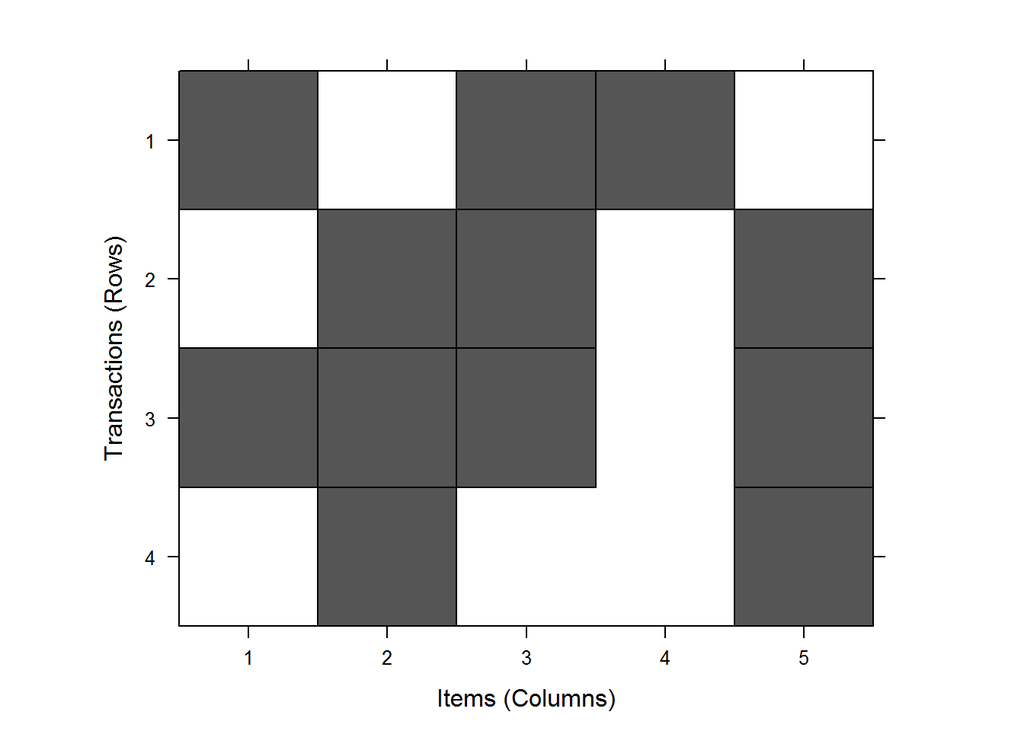

```r
image(tr)
```

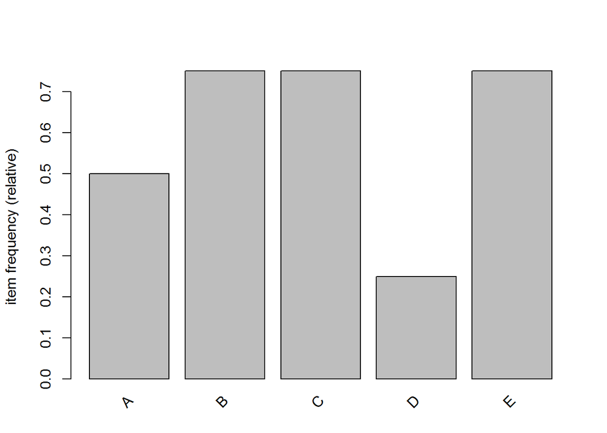

```r
itemFrequencyPlot(tr, support = 0.1)
```

```r
length
```

```
## function (x)  .Primitive("length")
```

## Create some rules using Apriori algorithm

The function to mine frequent itemsets, association rules or association hyperedges, using the Apriori algorithm:

```r
rules <- apriori(tr, parameter= list(supp=0.5, conf=0.5))
```

```
## Apriori
##
## Parameter specification:
##  confidence minval smax arem  aval originalSupport maxtime support minlen
##         0.5    0.1    1 none FALSE            TRUE       5     0.5      1
##  maxlen target   ext
##      10  rules FALSE
##
## Algorithmic control:
##  filter tree heap memopt load sort verbose
##     0.1 TRUE TRUE  FALSE TRUE    2    TRUE
##
## Absolute minimum support count: 2
##
## set item appearances ...[0 item(s)] done [0.00s].
## set transactions ...[5 item(s), 4 transaction(s)] done [0.00s].
## sorting and recoding items ... [4 item(s)] done [0.00s].
## creating transaction tree ... done [0.00s].
## checking subsets of size 1 2 3 done [0.00s].
## writing ... [15 rule(s)] done [0.00s].
## creating S4 object  ... done [0.00s].
```

```r
inspect(rules)
```

```
##      lhs      rhs support confidence lift      count
## [1]  {}    => {A} 0.50    0.5000000  1.0000000 2
## [2]  {}    => {B} 0.75    0.7500000  1.0000000 3
## [3]  {}    => {E} 0.75    0.7500000  1.0000000 3
## [4]  {}    => {C} 0.75    0.7500000  1.0000000 3
## [5]  {A}   => {C} 0.50    1.0000000  1.3333333 2
## [6]  {C}   => {A} 0.50    0.6666667  1.3333333 2
## [7]  {B}   => {E} 0.75    1.0000000  1.3333333 3
## [8]  {E}   => {B} 0.75    1.0000000  1.3333333 3
## [9]  {B}   => {C} 0.50    0.6666667  0.8888889 2
## [10] {C}   => {B} 0.50    0.6666667  0.8888889 2
## [11] {E}   => {C} 0.50    0.6666667  0.8888889 2
## [12] {C}   => {E} 0.50    0.6666667  0.8888889 2
## [13] {B,E} => {C} 0.50    0.6666667  0.8888889 2
## [14] {B,C} => {E} 0.50    1.0000000  1.3333333 2
## [15] {C,E} => {B} 0.50    1.0000000  1.3333333 2
```

```r
summary(rules)
```

```
## set of 15 rules
##
## rule length distribution (lhs + rhs):sizes
## 1 2 3
## 4 8 3
##
##    Min. 1st Qu.  Median    Mean 3rd Qu.    Max.
##   1.000   1.500   2.000   1.933   2.000   3.000
##
## summary of quality measures:
##     support         confidence          lift            count
##  Min.   :0.5000   Min.   :0.5000   Min.   :0.8889   Min.   :2.000
##  1st Qu.:0.5000   1st Qu.:0.6667   1st Qu.:0.8889   1st Qu.:2.000
##  Median :0.5000   Median :0.7500   Median :1.0000   Median :2.000
##  Mean   :0.5833   Mean   :0.7833   Mean   :1.0963   Mean   :2.333
##  3rd Qu.:0.7500   3rd Qu.:1.0000   3rd Qu.:1.3333   3rd Qu.:3.000
##  Max.   :0.7500   Max.   :1.0000   Max.   :1.3333   Max.   :3.000
##
## mining info:
##  data ntransactions support confidence
##    tr             4     0.5        0.5
```

## Case study

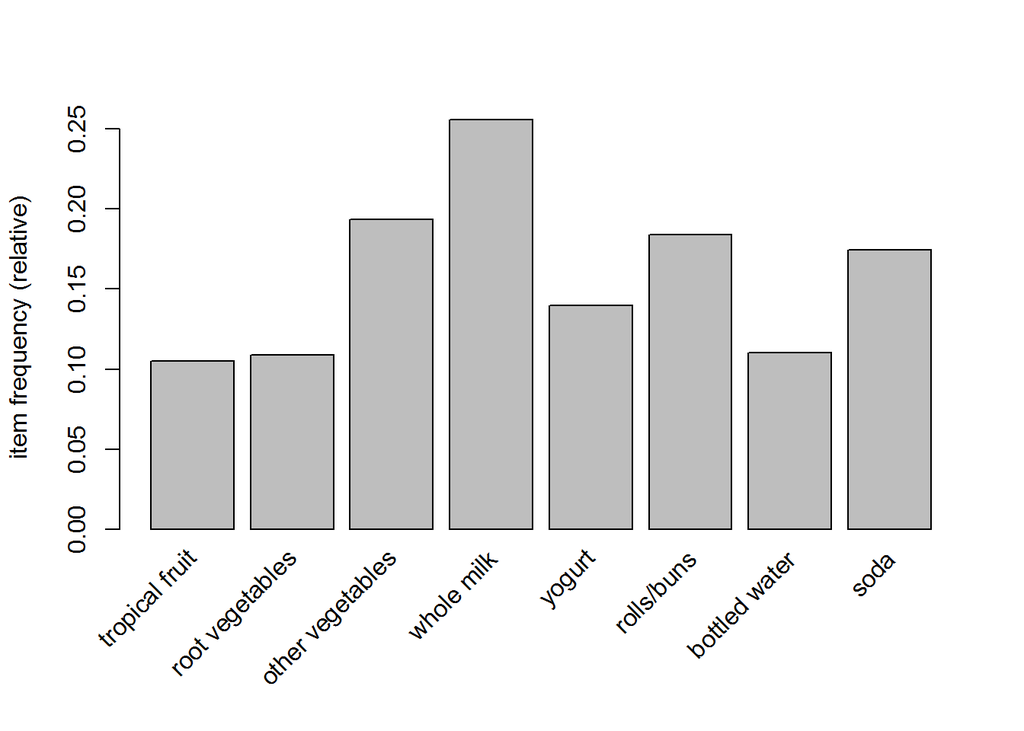

```r
data(Groceries)
tr <- Groceries
itemFrequencyPlot(tr, support = 0.1)
```

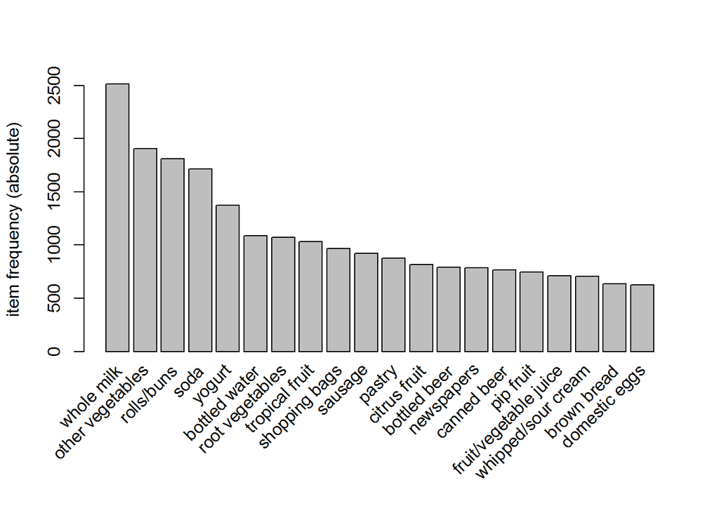

```r
itemFrequencyPlot(tr, topN=20, type='absolute')
```

```r
rules <- apriori(tr, parameter = list(supp=0.001, conf=0.8))
```

```
## Apriori
##
## Parameter specification:
##  confidence minval smax arem  aval originalSupport maxtime support minlen
##         0.8    0.1    1 none FALSE            TRUE       5   0.001      1
##  maxlen target   ext
##      10  rules FALSE
##
## Algorithmic control:
##  filter tree heap memopt load sort verbose
##     0.1 TRUE TRUE  FALSE TRUE    2    TRUE
##
## Absolute minimum support count: 9
##
## set item appearances ...[0 item(s)] done [0.00s].
## set transactions ...[169 item(s), 9835 transaction(s)] done [0.01s].
## sorting and recoding items ... [157 item(s)] done [0.02s].
## creating transaction tree ... done [0.00s].
## checking subsets of size 1 2 3 4 5 6 done [0.08s].
## writing ... [410 rule(s)] done [0.01s].
## creating S4 object  ... done [0.00s].
```

```r
rules <- sort(rules, by='confidence', decreasing = TRUE)
summary(rules)
```

```
## set of 410 rules
##
## rule length distribution (lhs + rhs):sizes
##   3   4   5   6
##  29 229 140  12
##
##    Min. 1st Qu.  Median    Mean 3rd Qu.    Max.
##   3.000   4.000   4.000   4.329   5.000   6.000
##
## summary of quality measures:
##     support           confidence          lift            count
##  Min.   :0.001017   Min.   :0.8000   Min.   : 3.131   Min.   :10.00
##  1st Qu.:0.001017   1st Qu.:0.8333   1st Qu.: 3.312   1st Qu.:10.00
##  Median :0.001220   Median :0.8462   Median : 3.588   Median :12.00
##  Mean   :0.001247   Mean   :0.8663   Mean   : 3.951   Mean   :12.27
##  3rd Qu.:0.001322   3rd Qu.:0.9091   3rd Qu.: 4.341   3rd Qu.:13.00
##  Max.   :0.003152   Max.   :1.0000   Max.   :11.235   Max.   :31.00
##
## mining info:
##  data ntransactions support confidence
##    tr          9835   0.001        0.8
```

```r
topRules <- rules[1:5]
inspect(topRules)
```

```
##     lhs                     rhs              support confidence     lift count
## [1] {rice,
##      sugar}              => {whole milk} 0.001220132          1 3.913649    12
## [2] {canned fish,
##      hygiene articles}   => {whole milk} 0.001118454          1 3.913649    11
## [3] {root vegetables,
##      butter,
##      rice}               => {whole milk} 0.001016777          1 3.913649    10
## [4] {root vegetables,
##      whipped/sour cream,
##      flour}              => {whole milk} 0.001728521          1 3.913649    17
## [5] {butter,
##      soft cheese,
##      domestic eggs}      => {whole milk} 0.001016777          1 3.913649    10
```

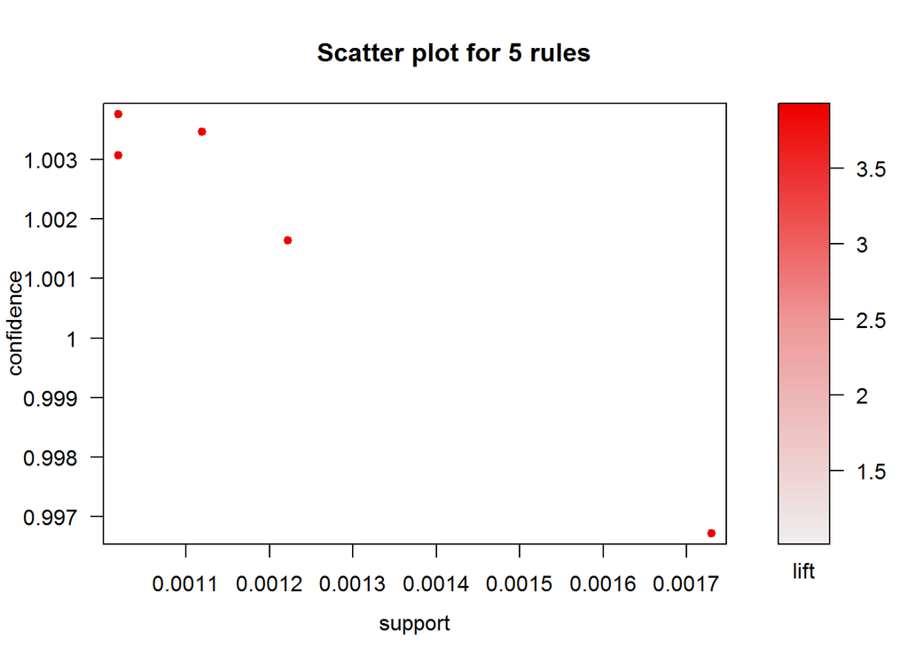

```r
library(arulesViz)
plot(topRules)
```

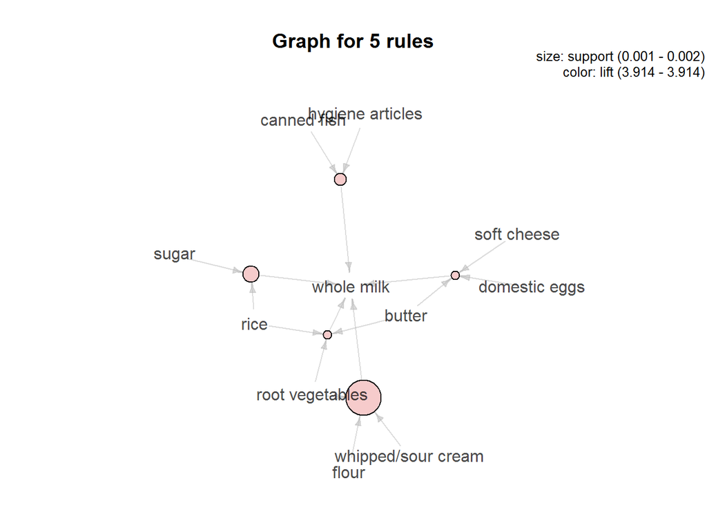

```r
plot(topRules, method="graph")
```

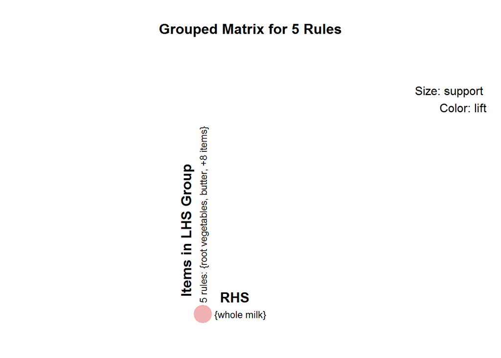

```r
plot(topRules, method = "grouped")
```